# AIML Module Project - Applied Statistics - Aaditya Kumar Ravi

## Part A

| Planned to purchase Product A | Actually placed an order for Product A - Yes | Actually placed an order for Product A - No | Total |
| --- | --- | --- | --- |
| **Yes** | 400 | 100 | 500 |
| **No** | 200 | 1300 | 1500 |
| **Total** | 600 | 1400 | 2000 |

##### Q1.A. Refer above table and find the joint probability of the people who planned to purchase and actually placed an order. [1 Mark]

```python
#People who planned and actually placed order PY
PY = 400
#Total People
TP = 2000
#joint probability of the people who planned to purchase and actually placed an order
P = 400/2000
print("joint probability of the people who planned to purchase and actually placed an order:",P)
```

```
joint probability of the people who planned to purchase and actually placed an order: 0.2
```

##### 1.B. Refer to the above table and find the joint probability of the people who planned to purchase and actually placed an order, given that people planned to purchase. [1 Mark]

```python
#People who planned to purchase and actualy placed an order
PY = 400
#Total Planned to Purchase
TPP = 500
#Total People
TP = 2000
#joint probability of the people who planned to purchase and actually placed an order, given that people planned to purchase
P = (400/2000)/(500/2000)
print("joint probability of the people who planned to purchase and actually placed an order, given that people planned to purchase:",P)
```

```
joint probability of the people who planned to purchase and actually placed an order, given that people planned to purchase: 0.8
```

##### 2. An electrical manufacturing company conducts quality checks at specified periods on the products it manufactures. Historically, the failure rate for the manufactured item is 5%. Suppose a random sample of 10 manufactured items is selected. Answer the following questions. [4 Marks]

```python
import numpy as np
import scipy.stats as stats
n=10 #Sample size
p=0.05 #Failure rate of the manufactured item
k=np.arange(0,11) #Array of quantiles
binomial = stats.binom.pmf(k,n,p)
binomial
```

```
array([5.98736939e-01, 3.15124705e-01, 7.46347985e-02, 1.04750594e-02,
       9.64808106e-04, 6.09352488e-05, 2.67259863e-06, 8.03789062e-08,
       1.58642578e-09, 1.85546875e-11, 9.76562500e-14])
```

##### 2.A. Probability that none of the items are defective? [1 Mark]

```python
print("Probability that none of the items are defective: ",binomial[0])
```

```
Probability that none of the items are defective:  0.5987369392383787
```

##### 2.B. Probability that exactly one of the items is defective? [1 Mark]

```python
print("Probability that exactly one of the items is defective: ",binomial[1])
```

```
Probability that exactly one of the items is defective:  0.3151247048623047
```

##### 2.C. Probability that two or fewer of the items are defective? [1 Mark]

```python
binomial_c = stats.binom.cdf(k,n,p)
print("Probability that two or fewer of the items are defective: ",binomial_c[2])
```

```
Probability that two or fewer of the items are defective:  0.9884964426207031
```

##### 2.D. Probability that three or more of the items are defective ? [1 Mark]

```python
print("Probability that three or more of the items are defective: ",1-binomial_c[2])
```

```
Probability that three or more of the items are defective:  0.01150355737929687
```

##### 3. A car salesman sells on an average 3 cars per week.

```python
rate = 3
n=np.arange(0,17)
```

##### 3.A. What is Probability that in a given week he will sell some cars? [1 Mark]

```python
#cumulative poisson distribution
poisson_c = stats.poisson.cdf(n,rate)
#Probability that in a given week he will sell some cars
p=1-poisson_c[0]
print("Probability that in a given week he will sell some cars: ",p)
```

```
Probability that in a given week he will sell some cars:  0.950212931632136
```

##### 3.B. What is Probability that in a given week he will sell 2 or more but less than 5 cars? [1 Mark]

```python
#Probability that he sells less than 5 cars i.e upto 4 cars
P1 = poisson_c[4]
#Probability that he sells less than 2 cars i.e up to 1 car
P2 = poisson_c[1]
#Probability that in a given week he will sell 2 or more but less than 5 cars
P=P1-P2
print("Probability that in a given week he will sell 2 or more but less than 5 cars: ",P)
```

```
Probability that in a given week he will sell 2 or more but less than 5 cars:  0.6161149710523164
```

##### 3.C. Plot the poisson distribution function for cumulative probability of cars sold per-week vs number of cars sold per week. [1 Mark]

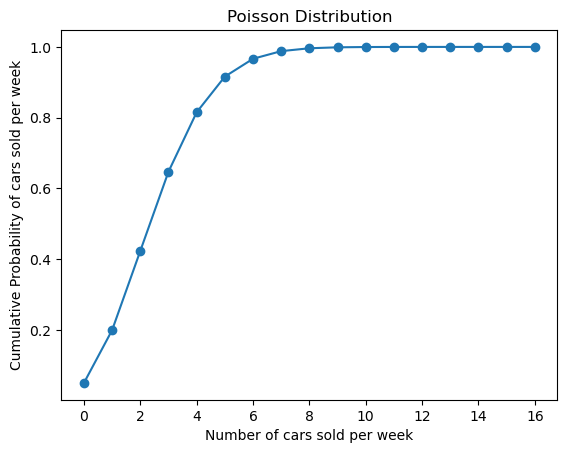

```python
import matplotlib.pyplot as plt
%matplotlib inline

plt.plot(n,poisson_c, 'o-')
plt.title('Poisson Distribution')
plt.xlabel('Number of cars sold per week')
plt.ylabel('Cumulative Probability of cars sold per week')
plt.show()
```

##### 4. Accuracy in understanding orders for a speech based bot at a restaurant is important for the Company X which has designed, marketed and launched the product for a contactless delivery due to the COVID-19 pandemic. Recognition accuracy that measures the percentage of orders that are taken correctly is 86.8%. Suppose that you place an order with the bot and two friends of yours independently place orders with the same bot. Answer the following questions. [3 Marks]

```python
p=0.868 #probability of orders that are taken correctly
n=3 #sample size
k=np.arange(0,5)
binomial = stats.binom.pmf(k,n,p)
```

##### 4.A. What is the probability that all three orders will be recognised correctly? [1 Mark]

```python
print("probability that all three orders will be recognised correctly: ",binomial[3])
```

```
probability that all three orders will be recognised correctly:  0.653972032
```

##### 4.B. What is the probability that none of the three orders will be recognised correctly? [1 Mark]

```python
print("probability that none of the three orders will be recognised correctly: ",binomial[0])
```

```
probability that none of the three orders will be recognised correctly:  0.0022999680000000003
```

##### 4.C. What is the probability that at least two of the three orders will be recognised correctly? [1 Mark]

```python
print("probability that at least two of the three orders will be recognised correctly: ",1-binomial[1])
```

[output not shown]

##### 5. Explain 1 real life industry scenario (other than the ones mentioned above) where you can use the concepts learnt in this module of Applied Statistics to get data driven business solution. [3 Marks]

#### Problem Statement

A company ABC every year provides AWS Solution Architect certification training to its 50 employees on first come first serve basis and gives the vouchure to appear in the exam at free of cost. The company has been doing this from last 7 years. The success rate to pass the certification exam is 60%.

#### Answer the following question?

Find the probility that none of the employee passes the exam?  
Find the probability that exactly 20 employees pass the exam?  
Find the probability that 25 or more passes the exam?

The above real life problem statement is based on Probability Distribution and Binomial Distribution

```
Probility that none of the employee passes the exam: 0.00000
Probability that exactly 20 employees pass the exam: 0.00199
Probability that 25 or more passes the exam: 0.94266
```

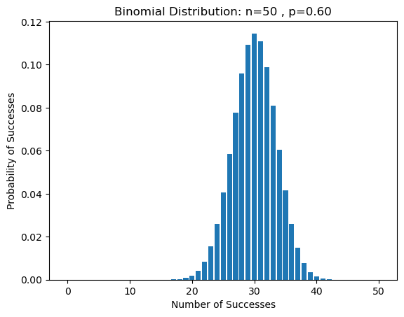

```python
n=50 #sample size
p=0.6 #probability to pass the certification exam based on historic data as given
k=np.arange(0,51) #array of quantiles
binomial=stats.binom.pmf(k,n,p) #probability mass function

#Find the probility that none of the employee passes the exam
print("Probility that none of the employee passes the exam: %.5f" %binomial[0])

#Find the probability that exactly 20 employees pass the exam
print("Probability that exactly 20 employees pass the exam: %.5f" %binomial[20])

#Find the probability that 25 or more passes the exam
binomial_c=stats.binom.cdf(k,n,p) #cumulative density function
print("Probability that 25 or more passes the exam: %.5f" %(1-binomial_c[24]))

# Let us plot the distribution for number of successes and its probability
plt.bar(k, binomial)
plt.title("Binomial Distribution: n=%i , p=%.2f" % (n, p))
plt.xlabel("Number of Successes")
plt.ylabel("Probability of Successes")
plt.show()
```

## Part B

##### DOMAIN: Sports

*• CONTEXT:* Company X manages the men's top professional basketball division of the American league system. The dataset contains information on all the teams that have participated in all the past tournaments. It has data about how many baskets each team scored, conceded, how many times they came within the first 2 positions, how many tournaments they have qualified, their best position in the past, etc.  
*• DATA DESCRIPTION:* Basketball.csv - The data set contains information on all the teams so far participated in all the past tournaments.  
*• DATA DICTIONARY:*

1. *Team:* Team’s name
2. *Tournament:* Number of played tournaments.
3. *Score:* Team’s score so far.
4. *PlayedGames:* Games played by the team so far.
5. *WonGames:* Games won by the team so far.
6. *DrawnGames:* Games drawn by the team so far.
7. *LostGames:* Games lost by the team so far.
8. *BasketScored:* Basket scored by the team so far.
9. *BasketGiven:* Basket scored against the team so far.
10. *TournamentChampion:* How many times the team was a champion of the tournaments so far.
11. *Runner-up:* How many times the team was a runners-up of the tournaments so far.
12. *TeamLaunch:* Year the team was launched on professional basketball.
13. *HighestPositionHeld:* Highest position held by the team amongst all the tournaments played.  
    *• PROJECT OBJECTIVE:* Company’s management wants to invest on proposals on managing some of the best teams in the league. The analytics department has been assigned with a task of creating a report on the performance shown by the teams. Some of the older teams are already in contract with competitors. Hence Company X wants to understand which teams they can approach which will be a deal win for them.

    ##### STEPS AND TASK [30 Marks]:

##### 1. Read the data set, clean the data and prepare final dataset to be used for analysis. [10 Marks]

```python
import pandas as pd
df=pd.read_csv('Basketball.csv') #import the dataset
df.info() #information about dataset structure
```

```
<class 'pandas.core.frame.DataFrame'>
RangeIndex: 61 entries, 0 to 60
Data columns (total 13 columns):
 #   Column               Non-Null Count  Dtype
---  ------               --------------  -----
 0   Team                 61 non-null     object
 1   Tournament           61 non-null     int64
 2   Score                61 non-null     object
 3   PlayedGames          61 non-null     object
 4   WonGames             61 non-null     object
 5   DrawnGames           61 non-null     object
 6   LostGames            61 non-null     object
 7   BasketScored         61 non-null     object
 8   BasketGiven          61 non-null     object
 9   TournamentChampion   61 non-null     object
 10  Runner-up            61 non-null     object
 11  TeamLaunch           61 non-null     object
 12  HighestPositionHeld  61 non-null     int64
dtypes: int64(2), object(11)
memory usage: 6.3+ KB
```

#### Observations:

- Total 61 entries in the above dataset
- None of the value is null
- There are total 2 columns as Int and 11 columns as object
- Some of the columns(Score, Played Games, WonGames, Drawn Games, Lost Games, Basket Scored, Basket Given, Tournament Champion, Runner-up) are of object type but it should be numerical column

#### Sanity Checks

```python
df.head() #display first 5 records
```

|  | Team | Tournament | Score | PlayedGames | WonGames | DrawnGames | LostGames | BasketScored | BasketGiven | TournamentChampion | Runner-up | TeamLaunch | HighestPositionHeld |
| --- | --- | --- | --- | --- | --- | --- | --- | --- | --- | --- | --- | --- | --- |
| 0 | Team 1 | 86 | 4385 | 2762 | 1647 | 552 | 563 | 5947 | 3140 | 33 | 23 | 1929 | 1 |
| 1 | Team 2 | 86 | 4262 | 2762 | 1581 | 573 | 608 | 5900 | 3114 | 25 | 25 | 1929 | 1 |
| 2 | Team 3 | 80 | 3442 | 2614 | 1241 | 598 | 775 | 4534 | 3309 | 10 | 8 | 1929 | 1 |
| 3 | Team 4 | 82 | 3386 | 2664 | 1187 | 616 | 861 | 4398 | 3469 | 6 | 6 | 1931to32 | 1 |
| 4 | Team 5 | 86 | 3368 | 2762 | 1209 | 633 | 920 | 4631 | 3700 | 8 | 7 | 1929 | 1 |

```python
df.tail() #displays last 5 records
```

|  | Team | Tournament | Score | PlayedGames | WonGames | DrawnGames | LostGames | BasketScored | BasketGiven | TournamentChampion | Runner-up | TeamLaunch | HighestPositionHeld |
| --- | --- | --- | --- | --- | --- | --- | --- | --- | --- | --- | --- | --- | --- |
| 56 | Team 57 | 1 | 34 | 38 | 8 | 10 | 20 | 38 | 66 | - | - | 2009-10 | 20 |
| 57 | Team 58 | 1 | 22 | 30 | 7 | 8 | 15 | 37 | 57 | - | - | 1956-57 | 16 |
| 58 | Team 59 | 1 | 19 | 30 | 7 | 5 | 18 | 51 | 85 | - | - | 1951~52 | 16 |
| 59 | Team 60 | 1 | 14 | 30 | 5 | 4 | 21 | 34 | 65 | - | - | 1955-56 | 15 |
| 60 | Team 61 | 1 | - | - | - | - | - | - | - | - | - | 2017~18 | 9 |

#### Observation

- some of the values are just hyphen (-) instead of null, which is also equivalent to null

```python
print("Rows in the dataset: ", df.shape[0])
print("Columns in the dataset: ", df.shape[1])
```

```
Rows in the dataset:  61
Columns in the dataset:  13
```

```python
df.describe()
```

|  | Tournament | HighestPositionHeld |
| --- | --- | --- |
| count | 61.000000 | 61.000000 |
| mean | 24.000000 | 7.081967 |
| std | 26.827225 | 5.276663 |
| min | 1.000000 | 1.000000 |
| 25% | 4.000000 | 3.000000 |
| 50% | 12.000000 | 6.000000 |
| 75% | 38.000000 | 10.000000 |
| max | 86.000000 | 20.000000 |

#### Check the non-numeric values and their count to replace it with null and then change the datatype

- Score, Played Games, WonGames, Drawn Games, Lost Games, Basket Scored, Basket Given, Tournament Champion, Runner-up are of object type but it should be numerical column

```python
df['Score'].unique()
```

```
array(['4385', '4262', '3442', '3386', '3368', '2819', '2792', '2573',
       '2109', '1884', '1814', '1789', '1471', '1416', '1389', '1351',
       '1314', '1174', '1148', '1020', '970', '667', '662', '606', '553',
       '538', '510', '445', '421', '416', '375', '353', '343', '293',
       '285', '277', '242', '230', '190', '188', '168', '150', '148',
       '132', '107', '96', '91', '83', '81', '76', '71', '56', '52', '42',
       '40', '35', '34', '22', '19', '14', '-'], dtype=object)
```

- Non numeric value Hyphen (-) is present for Score column

```python
df.loc[df['Score']=='-']
```

|  | Team | Tournament | Score | PlayedGames | WonGames | DrawnGames | LostGames | BasketScored | BasketGiven | TournamentChampion | Runner-up | TeamLaunch | HighestPositionHeld |
| --- | --- | --- | --- | --- | --- | --- | --- | --- | --- | --- | --- | --- | --- |
| 60 | Team 61 | 1 | - | - | - | - | - | - | - | - | - | 2017~18 | 9 |

- Just one row Hyphen value for Score column

```python
df['PlayedGames'].unique()
```

```
array(['2762', '2614', '2664', '2408', '2626', '2302', '1986', '1728',
       '1530', '1698', '1466', '1428', '1458', '1318', '1255', '1192',
       '988', '1096', '646', '742', '652', '678', '456', '628', '494',
       '586', '380', '402', '423', '426', '448', '346', '334', '270',
       '228', '282', '160', '186', '204', '180', '152', '114', '130',
       '116', '80', '108', '90', '72', '68', '54', '38', '30', '-'],
      dtype=object)
```

- Non numeric value Hyphen (-) is present for PlayedGames column

```python
df.loc[df['PlayedGames']=='-']
```

|  | Team | Tournament | Score | PlayedGames | WonGames | DrawnGames | LostGames | BasketScored | BasketGiven | TournamentChampion | Runner-up | TeamLaunch | HighestPositionHeld |
| --- | --- | --- | --- | --- | --- | --- | --- | --- | --- | --- | --- | --- | --- |
| 60 | Team 61 | 1 | - | - | - | - | - | - | - | - | - | 2017~18 | 9 |

- Just one row Hyphen value for PlayedGames column

```python
df['WonGames'].unique()
```

```
array(['1647', '1581', '1241', '1187', '1209', '990', '948', '864', '698',
       '606', '563', '586', '463', '453', '471', '426', '390', '408',
       '333', '367', '266', '218', '189', '203', '147', '184', '155',
       '145', '125', '113', '123', '129', '104', '96', '103', '76', '62',
       '82', '52', '50', '59', '53', '37', '35', '43', '26', '34', '20',
       '19', '30', '29', '21', '17', '18', '13', '8', '7', '5', '-'],
      dtype=object)
```

- Non numeric value Hyphen (-) is present for WonGames column

```python
df.loc[df['WonGames']=='-']
```

|  | Team | Tournament | Score | PlayedGames | WonGames | DrawnGames | LostGames | BasketScored | BasketGiven | TournamentChampion | Runner-up | TeamLaunch | HighestPositionHeld |
| --- | --- | --- | --- | --- | --- | --- | --- | --- | --- | --- | --- | --- | --- |
| 60 | Team 61 | 1 | - | - | - | - | - | - | - | - | - | 2017~18 | 9 |

- Just one row Hyphen value for WonGames column

```python
df['DrawnGames'].unique()
```

```
array(['552', '573', '598', '616', '633', '531', '608', '577', '522',
       '440', '392', '389', '384', '336', '358', '327', '330', '292',
       '256', '242', '172', '175', '148', '180', '112', '149', '128',
       '143', '81', '95', '102', '127', '92', '79', '76', '56', '63',
       '45', '46', '50', '44', '37', '27', '21', '16', '23', '24', '13',
       '14', '18', '6', '11', '10', '8', '5', '4', '-'], dtype=object)
```

- Non-numeric Hyphen (-) is present from DrawnGames column

```python
df.loc[df['DrawnGames']=='-']
```

|  | Team | Tournament | Score | PlayedGames | WonGames | DrawnGames | LostGames | BasketScored | BasketGiven | TournamentChampion | Runner-up | TeamLaunch | HighestPositionHeld |
| --- | --- | --- | --- | --- | --- | --- | --- | --- | --- | --- | --- | --- | --- |
| 60 | Team 61 | 1 | - | - | - | - | - | - | - | - | - | 2017~18 | 9 |

- Just one row Hyphen value for DrawnGames

```python
df['LostGames'].unique()
```

```
array(['563', '608', '775', '861', '920', '887', '1070', '766', '682',
       '575', '723', '619', '639', '629', '565', '535', '492', '399',
       '487', '208', '349', '305', '295', '197', '211', '298', '174',
       '194', '198', '202', '217', '158', '152', '118', '110', '137',
       '63', '90', '95', '83', '78', '52', '66', '44', '37', '62', '48',
       '33', '30', '41', '19', '20', '15', '18', '21', '-'], dtype=object)
```

- Non-numeric Hyphen (-) is present from LostGames column

```python
df.loc[df['LostGames']=='-']
```

|  | Team | Tournament | Score | PlayedGames | WonGames | DrawnGames | LostGames | BasketScored | BasketGiven | TournamentChampion | Runner-up | TeamLaunch | HighestPositionHeld |
| --- | --- | --- | --- | --- | --- | --- | --- | --- | --- | --- | --- | --- | --- |
| 60 | Team 61 | 1 | - | - | - | - | - | - | - | - | - | 2017~18 | 9 |

- Just one row with Hyphen value for LostGames Column

```python
df['BasketScored'].unique()
```

```
array(['5947', '5900', '4534', '4398', '4631', '3680', '3609', '3228',
       '2683', '2159', '2052', '2278', '1767', '1843', '1753', '1500',
       '1421', '1642', '1182', '1347', '892', '819', '760', '750', '520',
       '716', '619', '607', '458', '430', '422', '492', '393', '291',
       '419', '320', '244', '285', '199', '202', '216', '165', '155',
       '139', '227', '101', '181', '62', '70', '145', '121', '153', '71',
       '97', '36', '38', '37', '51', '34', '-'], dtype=object)
```

- Non-numeric Hyphen (-) is present from BasketScored column

```python
df.loc[df['BasketScored']=='-']
```

|  | Team | Tournament | Score | PlayedGames | WonGames | DrawnGames | LostGames | BasketScored | BasketGiven | TournamentChampion | Runner-up | TeamLaunch | HighestPositionHeld |
| --- | --- | --- | --- | --- | --- | --- | --- | --- | --- | --- | --- | --- | --- |
| 60 | Team 61 | 1 | - | - | - | - | - | - | - | - | - | 2017~18 | 9 |

- Just one row with Hyphen value for BasketScored Column

```python
df['BasketGiven'].unique()
```

```
array(['3140', '3114', '3309', '3469', '3700', '3373', '3889', '3230',
       '2847', '2492', '2188', '2624', '2180', '2368', '2152', '1834',
       '1763', '1951', '1371', '1746', '789', '1157', '1088', '1022',
       '633', '1050', '744', '992', '623', '632', '581', '720', '662',
       '489', '588', '410', '366', '430', '241', '296', '310', '221',
       '253', '167', '308', '139', '295', '117', '115', '252', '183',
       '184', '116', '131', '182', '55', '66', '57', '85', '65', '-'],
      dtype=object)
```

- Non-numeric Hyphen (-) is present from BasketGiven column

```python
df.loc[df['BasketGiven']=='-']
```

|  | Team | Tournament | Score | PlayedGames | WonGames | DrawnGames | LostGames | BasketScored | BasketGiven | TournamentChampion | Runner-up | TeamLaunch | HighestPositionHeld |
| --- | --- | --- | --- | --- | --- | --- | --- | --- | --- | --- | --- | --- | --- |
| 60 | Team 61 | 1 | - | - | - | - | - | - | - | - | - | 2017~18 | 9 |

- Non-numeric Hyphen (-) is present from BasketGiven column

```python
df['TournamentChampion'].unique()
```

```
array(['33', '25', '10', '6', '8', '1', '-', '2'], dtype=object)
```

```python
df.loc[df['TournamentChampion']=='-']['TournamentChampion'].count()
```

```
52
```

- Total 52 rows with Hyphen value for TournamentChampion column

```python
df['Runner-up'].unique()
```

```
array(['23', '25', '8', '6', '7', '4', '-', '3', '1', '5'], dtype=object)
```

```python
df.loc[df['Runner-up']=='-']['Runner-up'].count()
```

```
48
```

- Total 48 rows with Hyphen value for Runner-up column

#### Observation from above

- Row with index number 60 has most of the columns having Hyphen(-) value with just one row
- Those columns(Score, Played Games, WonGames, Drawn Games, Lost Games, Basket Scored, Basket Given) which have exactly one Hyphen value count is only with last row index 60
- 52 rows with Hyphen value for TournamentChampion column
- 48 rows with Hyphen value for Runner-up column

#### Let us replace Hyphen(-) to NaN while loading the data.

```python
df_new = pd.read_csv("Basketball.csv",na_values=['-']) #replace - with NaN
df_new.info()
```

```
<class 'pandas.core.frame.DataFrame'>
RangeIndex: 61 entries, 0 to 60
Data columns (total 13 columns):
 #   Column               Non-Null Count  Dtype
---  ------               --------------  -----
 0   Team                 61 non-null     object
 1   Tournament           61 non-null     int64
 2   Score                60 non-null     float64
 3   PlayedGames          60 non-null     float64
 4   WonGames             60 non-null     float64
 5   DrawnGames           60 non-null     float64
 6   LostGames            60 non-null     float64
 7   BasketScored         60 non-null     float64
 8   BasketGiven          60 non-null     float64
 9   TournamentChampion   9 non-null      float64
 10  Runner-up            13 non-null     float64
 11  TeamLaunch           61 non-null     object
 12  HighestPositionHeld  61 non-null     int64
dtypes: float64(9), int64(2), object(2)
memory usage: 6.3+ KB
```

- After replacing Hyphen(-) with NaN values, we see object datatype for columns(Score, PlayedGames, WonGames, DrawnGames, LostGames, BasketScored, BasketGiven, TournamentChampion, Runner-up) is automatically changed to numeric type i.e float64

```python
df_new.tail() #read the replaced values of last 5 rows
```

|  | Team | Tournament | Score | PlayedGames | WonGames | DrawnGames | LostGames | BasketScored | BasketGiven | TournamentChampion | Runner-up | TeamLaunch | HighestPositionHeld |
| --- | --- | --- | --- | --- | --- | --- | --- | --- | --- | --- | --- | --- | --- |
| 56 | Team 57 | 1 | 34.0 | 38.0 | 8.0 | 10.0 | 20.0 | 38.0 | 66.0 | NaN | NaN | 2009-10 | 20 |
| 57 | Team 58 | 1 | 22.0 | 30.0 | 7.0 | 8.0 | 15.0 | 37.0 | 57.0 | NaN | NaN | 1956-57 | 16 |
| 58 | Team 59 | 1 | 19.0 | 30.0 | 7.0 | 5.0 | 18.0 | 51.0 | 85.0 | NaN | NaN | 1951~52 | 16 |
| 59 | Team 60 | 1 | 14.0 | 30.0 | 5.0 | 4.0 | 21.0 | 34.0 | 65.0 | NaN | NaN | 1955-56 | 15 |
| 60 | Team 61 | 1 | NaN | NaN | NaN | NaN | NaN | NaN | NaN | NaN | NaN | 2017~18 | 9 |

```python
df_new.isnull().sum()
```

```
Team                    0
Tournament              0
Score                   1
PlayedGames             1
WonGames                1
DrawnGames              1
LostGames               1
BasketScored            1
BasketGiven             1
TournamentChampion     52
Runner-up              48
TeamLaunch              0
HighestPositionHeld     0
dtype: int64
```

- Since most of the values are null in row index 60, That rows does not make much sense, so let us drop that row and fix single null value for Score, PlayedGames, WonGames, DrawnGames, LostGames, BasketScored, BasketGiven columns

```python
df_new = df_new.drop(60).reset_index(drop=True)
```

```python
df_new #read the data
```

|  | Team | Tournament | Score | PlayedGames | WonGames | DrawnGames | LostGames | BasketScored | BasketGiven | TournamentChampion | Runner-up | TeamLaunch | HighestPositionHeld |
| --- | --- | --- | --- | --- | --- | --- | --- | --- | --- | --- | --- | --- | --- |
| 0 | Team 1 | 86 | 4385.0 | 2762.0 | 1647.0 | 552.0 | 563.0 | 5947.0 | 3140.0 | 33.0 | 23.0 | 1929 | 1 |
| 1 | Team 2 | 86 | 4262.0 | 2762.0 | 1581.0 | 573.0 | 608.0 | 5900.0 | 3114.0 | 25.0 | 25.0 | 1929 | 1 |
| 2 | Team 3 | 80 | 3442.0 | 2614.0 | 1241.0 | 598.0 | 775.0 | 4534.0 | 3309.0 | 10.0 | 8.0 | 1929 | 1 |
| 3 | Team 4 | 82 | 3386.0 | 2664.0 | 1187.0 | 616.0 | 861.0 | 4398.0 | 3469.0 | 6.0 | 6.0 | 1931to32 | 1 |
| 4 | Team 5 | 86 | 3368.0 | 2762.0 | 1209.0 | 633.0 | 920.0 | 4631.0 | 3700.0 | 8.0 | 7.0 | 1929 | 1 |
| 5 | Team 6 | 73 | 2819.0 | 2408.0 | 990.0 | 531.0 | 887.0 | 3680.0 | 3373.0 | 1.0 | 4.0 | 1934-35 | 1 |
| 6 | Team 7 | 82 | 2792.0 | 2626.0 | 948.0 | 608.0 | 1070.0 | 3609.0 | 3889.0 | NaN | NaN | 1929 | 3 |
| 7 | Team 8 | 70 | 2573.0 | 2302.0 | 864.0 | 577.0 | 861.0 | 3228.0 | 3230.0 | 2.0 | 3.0 | 1929 | 1 |
| 8 | Team 9 | 58 | 2109.0 | 1986.0 | 698.0 | 522.0 | 766.0 | 2683.0 | 2847.0 | NaN | 1.0 | 1939-40 | 2 |
| 9 | Team 10 | 51 | 1884.0 | 1728.0 | 606.0 | 440.0 | 682.0 | 2159.0 | 2492.0 | 1.0 | NaN | 1932-33 | 1 |
| 10 | Team 11 | 45 | 1814.0 | 1530.0 | 563.0 | 392.0 | 575.0 | 2052.0 | 2188.0 | 1.0 | 5.0 | 1941to42 | 1 |
| 11 | Team 12 | 51 | 1789.0 | 1698.0 | 586.0 | 389.0 | 723.0 | 2278.0 | 2624.0 | NaN | NaN | 1939-40 | 4 |
| 12 | Team 13 | 42 | 1471.0 | 1466.0 | 463.0 | 384.0 | 619.0 | 1767.0 | 2180.0 | NaN | NaN | 1948-49 | 4 |
| 13 | Team 14 | 44 | 1416.0 | 1428.0 | 453.0 | 336.0 | 639.0 | 1843.0 | 2368.0 | NaN | 1.0 | 1929 | 2 |
| 14 | Team 15 | 43 | 1389.0 | 1458.0 | 471.0 | 358.0 | 629.0 | 1753.0 | 2152.0 | NaN | 1.0 | 1944_45 | 2 |
| 15 | Team 16 | 37 | 1351.0 | 1318.0 | 426.0 | 327.0 | 565.0 | 1500.0 | 1834.0 | NaN | NaN | 1935-36 | 4 |
| 16 | Team 17 | 36 | 1314.0 | 1255.0 | 390.0 | 330.0 | 535.0 | 1421.0 | 1763.0 | NaN | NaN | 1949_50 | 4 |
| 17 | Team 18 | 38 | 1174.0 | 1192.0 | 408.0 | 292.0 | 492.0 | 1642.0 | 1951.0 | NaN | NaN | 1933to34 | 3 |
| 18 | Team 19 | 27 | 1148.0 | 988.0 | 333.0 | 256.0 | 399.0 | 1182.0 | 1371.0 | NaN | NaN | 1960-61 | 3 |
| 19 | Team 20 | 33 | 1020.0 | 1096.0 | 367.0 | 242.0 | 487.0 | 1347.0 | 1746.0 | NaN | 1.0 | 1951-52 | 2 |
| 20 | Team 21 | 17 | 970.0 | 646.0 | 266.0 | 172.0 | 208.0 | 892.0 | 789.0 | NaN | 1.0 | 1998-99 | 2 |
| 21 | Team 22 | 23 | 667.0 | 742.0 | 218.0 | 175.0 | 349.0 | 819.0 | 1157.0 | NaN | NaN | 1941-42 | 6 |
| 22 | Team 23 | 17 | 662.0 | 652.0 | 189.0 | 148.0 | 305.0 | 760.0 | 1088.0 | NaN | NaN | 1977-78 | 8 |
| 23 | Team 24 | 21 | 606.0 | 678.0 | 203.0 | 180.0 | 295.0 | 750.0 | 1022.0 | NaN | NaN | 1959-60 | 5 |
| 24 | Team 25 | 12 | 553.0 | 456.0 | 147.0 | 112.0 | 197.0 | 520.0 | 633.0 | NaN | NaN | 2004to05 | 6 |
| 25 | Team 26 | 20 | 538.0 | 628.0 | 184.0 | 149.0 | 295.0 | 716.0 | 1050.0 | NaN | NaN | 1935-36 | 5 |
| 26 | Team 27 | 13 | 510.0 | 494.0 | 155.0 | 128.0 | 211.0 | 619.0 | 744.0 | NaN | NaN | 1961-62 | 5 |
| 27 | Team 28 | 18 | 445.0 | 586.0 | 145.0 | 143.0 | 298.0 | 607.0 | 992.0 | NaN | NaN | 1940-41 | 11 |
| 28 | Team 29 | 12 | 421.0 | 380.0 | 125.0 | 81.0 | 174.0 | 458.0 | 623.0 | NaN | NaN | 1930-31 | 6 |
| 29 | Team 30 | 11 | 416.0 | 402.0 | 113.0 | 95.0 | 194.0 | 430.0 | 632.0 | NaN | NaN | 1963-64 | 6 |
| 30 | Team 31 | 12 | 375.0 | 423.0 | 123.0 | 102.0 | 198.0 | 422.0 | 581.0 | NaN | NaN | 1974-75 | 7 |
| 31 | Team 32 | 14 | 353.0 | 426.0 | 129.0 | 95.0 | 202.0 | 492.0 | 720.0 | NaN | NaN | 1943-44 | 4 |
| 32 | Team 33 | 12 | 343.0 | 448.0 | 104.0 | 127.0 | 217.0 | 393.0 | 662.0 | NaN | NaN | 1977-78 | 12 |
| 33 | Team 34 | 9 | 293.0 | 346.0 | 96.0 | 92.0 | 158.0 | 291.0 | 489.0 | NaN | NaN | 1987-88 | 7 |
| 34 | Team 35 | 11 | 285.0 | 334.0 | 103.0 | 79.0 | 152.0 | 419.0 | 588.0 | NaN | NaN | 1941-42 | 4 |
| 35 | Team 36 | 7 | 277.0 | 270.0 | 76.0 | 76.0 | 118.0 | 320.0 | 410.0 | NaN | NaN | 1991_92 | 7 |
| 36 | Team 37 | 6 | 242.0 | 228.0 | 62.0 | 56.0 | 110.0 | 244.0 | 366.0 | NaN | NaN | 2007-08 | 8 |
| 37 | Team 38 | 9 | 230.0 | 282.0 | 82.0 | 63.0 | 137.0 | 285.0 | 430.0 | NaN | NaN | 1962-63 | 5 |
| 38 | Team 39 | 4 | 190.0 | 160.0 | 52.0 | 45.0 | 63.0 | 199.0 | 241.0 | NaN | NaN | 1994-95 | 10 |
| 39 | Team 40 | 5 | 188.0 | 186.0 | 50.0 | 46.0 | 90.0 | 202.0 | 296.0 | NaN | NaN | 1978-79 | 8 |
| 40 | Team 41 | 6 | 168.0 | 204.0 | 59.0 | 50.0 | 95.0 | 216.0 | 310.0 | NaN | NaN | 1971-72 | 12 |
| 41 | Team 42 | 6 | 150.0 | 180.0 | 53.0 | 44.0 | 83.0 | 165.0 | 221.0 | NaN | NaN | 1963-64 | 7 |
| 42 | Team 43 | 4 | 148.0 | 152.0 | 37.0 | 37.0 | 78.0 | 155.0 | 253.0 | NaN | NaN | 1999to00 | 17 |
| 43 | Team 44 | 3 | 132.0 | 114.0 | 35.0 | 27.0 | 52.0 | 139.0 | 167.0 | NaN | NaN | 2014-15 | 10 |
| 44 | Team 45 | 7 | 107.0 | 130.0 | 43.0 | 21.0 | 66.0 | 227.0 | 308.0 | NaN | NaN | 1929 | 3 |
| 45 | Team 46 | 3 | 96.0 | 114.0 | 26.0 | 44.0 | 44.0 | 101.0 | 139.0 | NaN | NaN | 1990-91 | 9 |
| 46 | Team 47 | 4 | 91.0 | 116.0 | 34.0 | 16.0 | 66.0 | 181.0 | 295.0 | NaN | NaN | 1947-48 | 7 |
| 47 | Team 48 | 2 | 83.0 | 80.0 | 20.0 | 23.0 | 37.0 | 62.0 | 117.0 | NaN | NaN | 1996-97 | 17 |
| 48 | Team 49 | 2 | 81.0 | 80.0 | 19.0 | 24.0 | 37.0 | 70.0 | 115.0 | NaN | NaN | 1995-96 | 19 |
| 49 | Team 50 | 4 | 76.0 | 108.0 | 30.0 | 16.0 | 62.0 | 145.0 | 252.0 | NaN | NaN | 1945-46 | 10 |
| 50 | Team 51 | 3 | 71.0 | 90.0 | 29.0 | 13.0 | 48.0 | 121.0 | 183.0 | NaN | NaN | 1953-54 | 14 |
| 51 | Team 52 | 4 | 56.0 | 72.0 | 21.0 | 14.0 | 37.0 | 153.0 | 184.0 | NaN | NaN | 1929 | 6 |
| 52 | Team 53 | 2 | 52.0 | 68.0 | 17.0 | 18.0 | 33.0 | 71.0 | 116.0 | NaN | NaN | 1979-80 | 10 |
| 53 | Team 54 | 3 | 42.0 | 54.0 | 18.0 | 6.0 | 30.0 | 97.0 | 131.0 | NaN | NaN | 1929 | 8 |
| 54 | Team 55 | 2 | 40.0 | 68.0 | 13.0 | 14.0 | 41.0 | 70.0 | 182.0 | NaN | NaN | 1950-51 | 16 |
| 55 | Team 56 | 1 | 35.0 | 38.0 | 8.0 | 11.0 | 19.0 | 36.0 | 55.0 | NaN | NaN | 2016_17 | 17 |
| 56 | Team 57 | 1 | 34.0 | 38.0 | 8.0 | 10.0 | 20.0 | 38.0 | 66.0 | NaN | NaN | 2009-10 | 20 |
| 57 | Team 58 | 1 | 22.0 | 30.0 | 7.0 | 8.0 | 15.0 | 37.0 | 57.0 | NaN | NaN | 1956-57 | 16 |
| 58 | Team 59 | 1 | 19.0 | 30.0 | 7.0 | 5.0 | 18.0 | 51.0 | 85.0 | NaN | NaN | 1951~52 | 16 |
| 59 | Team 60 | 1 | 14.0 | 30.0 | 5.0 | 4.0 | 21.0 | 34.0 | 65.0 | NaN | NaN | 1955-56 | 15 |

```python
df_new.isnull().sum()
```

```
Team                    0
Tournament              0
Score                   0
PlayedGames             0
WonGames                0
DrawnGames              0
LostGames               0
BasketScored            0
BasketGiven             0
TournamentChampion     51
Runner-up              47
TeamLaunch              0
HighestPositionHeld     0
dtype: int64
```

- Now null value is with less number of columns just 2 TournamentChampion and Runner-up

```python
df.info()
```

```
<class 'pandas.core.frame.DataFrame'>
RangeIndex: 61 entries, 0 to 60
Data columns (total 13 columns):
 #   Column               Non-Null Count  Dtype
---  ------               --------------  -----
 0   Team                 61 non-null     object
 1   Tournament           61 non-null     int64
 2   Score                61 non-null     object
 3   PlayedGames          61 non-null     object
 4   WonGames             61 non-null     object
 5   DrawnGames           61 non-null     object
 6   LostGames            61 non-null     object
 7   BasketScored         61 non-null     object
 8   BasketGiven          61 non-null     object
 9   TournamentChampion   61 non-null     object
 10  Runner-up            61 non-null     object
 11  TeamLaunch           61 non-null     object
 12  HighestPositionHeld  61 non-null     int64
dtypes: int64(2), object(11)
memory usage: 6.3+ KB
```

```python
#change the datatype of numeric columns from object to int
df_new['Score']=df_new['Score'].astype('int64')
df_new['PlayedGames']=df_new['PlayedGames'].astype('int64')
df_new['WonGames']=df_new['WonGames'].astype('int64')
df_new['DrawnGames']=df_new['DrawnGames'].astype('int64')
df_new['LostGames']=df_new['LostGames'].astype('int64')
df_new['BasketScored']=df_new['BasketScored'].astype('int64')
df_new['BasketGiven']=df_new['BasketGiven'].astype('int64')
df_new['TournamentChampion']=df_new['TournamentChampion'].astype(float)
df_new['Runner-up']=df_new['Runner-up'].astype(float)
```

```python
df_new.info()
```

```
<class 'pandas.core.frame.DataFrame'>
RangeIndex: 60 entries, 0 to 59
Data columns (total 13 columns):
 #   Column               Non-Null Count  Dtype
---  ------               --------------  -----
 0   Team                 60 non-null     object
 1   Tournament           60 non-null     int64
 2   Score                60 non-null     int64
 3   PlayedGames          60 non-null     int64
 4   WonGames             60 non-null     int64
 5   DrawnGames           60 non-null     int64
 6   LostGames            60 non-null     int64
 7   BasketScored         60 non-null     int64
 8   BasketGiven          60 non-null     int64
 9   TournamentChampion   9 non-null      float64
 10  Runner-up            13 non-null     float64
 11  TeamLaunch           60 non-null     object
 12  HighestPositionHeld  60 non-null     int64
dtypes: float64(2), int64(9), object(2)
memory usage: 6.2+ KB
```

```python
df_new['TournamentChampion'].value_counts()
```

```
1.0     3
33.0    1
25.0    1
10.0    1
6.0     1
8.0     1
2.0     1
Name: TournamentChampion, dtype: int64
```

```python
df_new['Runner-up'].value_counts()
```

```
1.0     5
23.0    1
25.0    1
8.0     1
6.0     1
7.0     1
4.0     1
3.0     1
5.0     1
Name: Runner-up, dtype: int64
```

#### Observation and treatment action:

- Those who have null value in TournamentChampion and Runner-up columns, it may be that they never became Tournament Champion or Runner-up, Hence it is ideal to replace null with 0 value.

```python
df_new['TournamentChampion'] = df_new['TournamentChampion'].replace([np.nan],0)
df_new['Runner-up'] = df_new['Runner-up'].replace([np.nan],0)
```

```python
df_new['TournamentChampion'] = df_new['TournamentChampion'].astype('int64')
df_new['Runner-up'] = df_new['Runner-up'].astype('int64')
```

```python
df_new.info()
```

```
<class 'pandas.core.frame.DataFrame'>
RangeIndex: 60 entries, 0 to 59
Data columns (total 13 columns):
 #   Column               Non-Null Count  Dtype
---  ------               --------------  -----
 0   Team                 60 non-null     object
 1   Tournament           60 non-null     int64
 2   Score                60 non-null     int64
 3   PlayedGames          60 non-null     int64
 4   WonGames             60 non-null     int64
 5   DrawnGames           60 non-null     int64
 6   LostGames            60 non-null     int64
 7   BasketScored         60 non-null     int64
 8   BasketGiven          60 non-null     int64
 9   TournamentChampion   60 non-null     int64
 10  Runner-up            60 non-null     int64
 11  TeamLaunch           60 non-null     object
 12  HighestPositionHeld  60 non-null     int64
dtypes: int64(11), object(2)
memory usage: 6.2+ KB
```

- All the missing values are treated with appropriate value and action
- Datatype is also fixed

#### Let us analyse TeamLaunch column

```python
df_new['TeamLaunch'].value_counts()
```

```
1929        10
1941-42      2
1939-40      2
1963-64      2
1935-36      2
1977-78      2
1994-95      1
1978-79      1
1971-72      1
1999to00     1
2014-15      1
1990-91      1
1947-48      1
1995-96      1
1996-97      1
2007-08      1
1945-46      1
1953-54      1
1979-80      1
1950-51      1
2016_17      1
2009-10      1
1956-57      1
1951~52      1
1962-63      1
1943-44      1
1991_92      1
1987-88      1
1934-35      1
1932-33      1
1941to42     1
1948-49      1
1944_45      1
1949_50      1
1933to34     1
1960-61      1
1951-52      1
1998-99      1
1959-60      1
2004to05     1
1961-62      1
1940-41      1
1930-31      1
1974-75      1
1931to32     1
1955-56      1
Name: TeamLaunch, dtype: int64
```

- TeamLaunch column has years in different formats: E.g
- 1929
- 1941-42 separated by Hyphen -
- 1999to00 separated by to
- 2016*17 separated by underscore*
- 1951~52 separated by tild ~
- 0 to 1 year difference in start and end year

#### Replace to, _ , ~ to - to make it similar to other values

```python
df_new['TeamLaunch'] = df_new['TeamLaunch'].replace(["to",'_','~'],'-',regex=True)
```

```python
#Adding a new column TeamLaunchStartYear
df_new['TeamLaunchStartYear'] = df_new['TeamLaunch'].str.split('-').str[0]
df_new['TeamLaunchStartYear'] = df_new['TeamLaunchStartYear'].astype('int64')
```

- we have converted the new column TeamLaunchStartYear as integer as we have just year and not the day,time,date,month etc. Hence taking it as integer would also work in case if we require any comparison with the year
- We will be introducing new column TeamLaunchEndYear of int64 type
- TeamLaunchEndYear is always going to be TeamLaunchStartYear + 1 except for year 1929 based on the current data observation from file

```python
#populate TeamLaunchEndYear values as per below condition
df_new['TeamLaunchEndYear'] = np.where(df_new['TeamLaunchStartYear']==1929,1929,df_new['TeamLaunchStartYear']+1)
```

```python
#we can drop TeamLaunch column as it looks like data in this format might not be needed for any comparision etc.
#and also we have derived TeamLaunchStartYear and TeamLaunchEndYear columns from this and converted in in useful data.
df_new.drop('TeamLaunch',axis=1,inplace=True)
```

```python
df_new.info()
```

```
<class 'pandas.core.frame.DataFrame'>
RangeIndex: 60 entries, 0 to 59
Data columns (total 14 columns):
 #   Column               Non-Null Count  Dtype
---  ------               --------------  -----
 0   Team                 60 non-null     object
 1   Tournament           60 non-null     int64
 2   Score                60 non-null     int64
 3   PlayedGames          60 non-null     int64
 4   WonGames             60 non-null     int64
 5   DrawnGames           60 non-null     int64
 6   LostGames            60 non-null     int64
 7   BasketScored         60 non-null     int64
 8   BasketGiven          60 non-null     int64
 9   TournamentChampion   60 non-null     int64
 10  Runner-up            60 non-null     int64
 11  HighestPositionHeld  60 non-null     int64
 12  TeamLaunchStartYear  60 non-null     int64
 13  TeamLaunchEndYear    60 non-null     int64
dtypes: int64(13), object(1)
memory usage: 6.7+ KB
```

```python
#Check if any duplicate row
df_new.duplicated().sum()
```

```
0
```

- 0 Duplicate rows

```python
#Let us read the data
df_new
```

|  | Team | Tournament | Score | PlayedGames | WonGames | DrawnGames | LostGames | BasketScored | BasketGiven | TournamentChampion | Runner-up | HighestPositionHeld | TeamLaunchStartYear | TeamLaunchEndYear |
| --- | --- | --- | --- | --- | --- | --- | --- | --- | --- | --- | --- | --- | --- | --- |
| 0 | Team 1 | 86 | 4385 | 2762 | 1647 | 552 | 563 | 5947 | 3140 | 33 | 23 | 1 | 1929 | 1929 |
| 1 | Team 2 | 86 | 4262 | 2762 | 1581 | 573 | 608 | 5900 | 3114 | 25 | 25 | 1 | 1929 | 1929 |
| 2 | Team 3 | 80 | 3442 | 2614 | 1241 | 598 | 775 | 4534 | 3309 | 10 | 8 | 1 | 1929 | 1929 |
| 3 | Team 4 | 82 | 3386 | 2664 | 1187 | 616 | 861 | 4398 | 3469 | 6 | 6 | 1 | 1931 | 1932 |
| 4 | Team 5 | 86 | 3368 | 2762 | 1209 | 633 | 920 | 4631 | 3700 | 8 | 7 | 1 | 1929 | 1929 |
| 5 | Team 6 | 73 | 2819 | 2408 | 990 | 531 | 887 | 3680 | 3373 | 1 | 4 | 1 | 1934 | 1935 |
| 6 | Team 7 | 82 | 2792 | 2626 | 948 | 608 | 1070 | 3609 | 3889 | 0 | 0 | 3 | 1929 | 1929 |
| 7 | Team 8 | 70 | 2573 | 2302 | 864 | 577 | 861 | 3228 | 3230 | 2 | 3 | 1 | 1929 | 1929 |
| 8 | Team 9 | 58 | 2109 | 1986 | 698 | 522 | 766 | 2683 | 2847 | 0 | 1 | 2 | 1939 | 1940 |
| 9 | Team 10 | 51 | 1884 | 1728 | 606 | 440 | 682 | 2159 | 2492 | 1 | 0 | 1 | 1932 | 1933 |
| 10 | Team 11 | 45 | 1814 | 1530 | 563 | 392 | 575 | 2052 | 2188 | 1 | 5 | 1 | 1941 | 1942 |
| 11 | Team 12 | 51 | 1789 | 1698 | 586 | 389 | 723 | 2278 | 2624 | 0 | 0 | 4 | 1939 | 1940 |
| 12 | Team 13 | 42 | 1471 | 1466 | 463 | 384 | 619 | 1767 | 2180 | 0 | 0 | 4 | 1948 | 1949 |
| 13 | Team 14 | 44 | 1416 | 1428 | 453 | 336 | 639 | 1843 | 2368 | 0 | 1 | 2 | 1929 | 1929 |
| 14 | Team 15 | 43 | 1389 | 1458 | 471 | 358 | 629 | 1753 | 2152 | 0 | 1 | 2 | 1944 | 1945 |
| 15 | Team 16 | 37 | 1351 | 1318 | 426 | 327 | 565 | 1500 | 1834 | 0 | 0 | 4 | 1935 | 1936 |
| 16 | Team 17 | 36 | 1314 | 1255 | 390 | 330 | 535 | 1421 | 1763 | 0 | 0 | 4 | 1949 | 1950 |
| 17 | Team 18 | 38 | 1174 | 1192 | 408 | 292 | 492 | 1642 | 1951 | 0 | 0 | 3 | 1933 | 1934 |
| 18 | Team 19 | 27 | 1148 | 988 | 333 | 256 | 399 | 1182 | 1371 | 0 | 0 | 3 | 1960 | 1961 |
| 19 | Team 20 | 33 | 1020 | 1096 | 367 | 242 | 487 | 1347 | 1746 | 0 | 1 | 2 | 1951 | 1952 |
| 20 | Team 21 | 17 | 970 | 646 | 266 | 172 | 208 | 892 | 789 | 0 | 1 | 2 | 1998 | 1999 |
| 21 | Team 22 | 23 | 667 | 742 | 218 | 175 | 349 | 819 | 1157 | 0 | 0 | 6 | 1941 | 1942 |
| 22 | Team 23 | 17 | 662 | 652 | 189 | 148 | 305 | 760 | 1088 | 0 | 0 | 8 | 1977 | 1978 |
| 23 | Team 24 | 21 | 606 | 678 | 203 | 180 | 295 | 750 | 1022 | 0 | 0 | 5 | 1959 | 1960 |
| 24 | Team 25 | 12 | 553 | 456 | 147 | 112 | 197 | 520 | 633 | 0 | 0 | 6 | 2004 | 2005 |
| 25 | Team 26 | 20 | 538 | 628 | 184 | 149 | 295 | 716 | 1050 | 0 | 0 | 5 | 1935 | 1936 |
| 26 | Team 27 | 13 | 510 | 494 | 155 | 128 | 211 | 619 | 744 | 0 | 0 | 5 | 1961 | 1962 |
| 27 | Team 28 | 18 | 445 | 586 | 145 | 143 | 298 | 607 | 992 | 0 | 0 | 11 | 1940 | 1941 |
| 28 | Team 29 | 12 | 421 | 380 | 125 | 81 | 174 | 458 | 623 | 0 | 0 | 6 | 1930 | 1931 |
| 29 | Team 30 | 11 | 416 | 402 | 113 | 95 | 194 | 430 | 632 | 0 | 0 | 6 | 1963 | 1964 |
| 30 | Team 31 | 12 | 375 | 423 | 123 | 102 | 198 | 422 | 581 | 0 | 0 | 7 | 1974 | 1975 |
| 31 | Team 32 | 14 | 353 | 426 | 129 | 95 | 202 | 492 | 720 | 0 | 0 | 4 | 1943 | 1944 |
| 32 | Team 33 | 12 | 343 | 448 | 104 | 127 | 217 | 393 | 662 | 0 | 0 | 12 | 1977 | 1978 |
| 33 | Team 34 | 9 | 293 | 346 | 96 | 92 | 158 | 291 | 489 | 0 | 0 | 7 | 1987 | 1988 |
| 34 | Team 35 | 11 | 285 | 334 | 103 | 79 | 152 | 419 | 588 | 0 | 0 | 4 | 1941 | 1942 |
| 35 | Team 36 | 7 | 277 | 270 | 76 | 76 | 118 | 320 | 410 | 0 | 0 | 7 | 1991 | 1992 |
| 36 | Team 37 | 6 | 242 | 228 | 62 | 56 | 110 | 244 | 366 | 0 | 0 | 8 | 2007 | 2008 |
| 37 | Team 38 | 9 | 230 | 282 | 82 | 63 | 137 | 285 | 430 | 0 | 0 | 5 | 1962 | 1963 |
| 38 | Team 39 | 4 | 190 | 160 | 52 | 45 | 63 | 199 | 241 | 0 | 0 | 10 | 1994 | 1995 |
| 39 | Team 40 | 5 | 188 | 186 | 50 | 46 | 90 | 202 | 296 | 0 | 0 | 8 | 1978 | 1979 |
| 40 | Team 41 | 6 | 168 | 204 | 59 | 50 | 95 | 216 | 310 | 0 | 0 | 12 | 1971 | 1972 |
| 41 | Team 42 | 6 | 150 | 180 | 53 | 44 | 83 | 165 | 221 | 0 | 0 | 7 | 1963 | 1964 |
| 42 | Team 43 | 4 | 148 | 152 | 37 | 37 | 78 | 155 | 253 | 0 | 0 | 17 | 1999 | 2000 |
| 43 | Team 44 | 3 | 132 | 114 | 35 | 27 | 52 | 139 | 167 | 0 | 0 | 10 | 2014 | 2015 |
| 44 | Team 45 | 7 | 107 | 130 | 43 | 21 | 66 | 227 | 308 | 0 | 0 | 3 | 1929 | 1929 |
| 45 | Team 46 | 3 | 96 | 114 | 26 | 44 | 44 | 101 | 139 | 0 | 0 | 9 | 1990 | 1991 |
| 46 | Team 47 | 4 | 91 | 116 | 34 | 16 | 66 | 181 | 295 | 0 | 0 | 7 | 1947 | 1948 |
| 47 | Team 48 | 2 | 83 | 80 | 20 | 23 | 37 | 62 | 117 | 0 | 0 | 17 | 1996 | 1997 |
| 48 | Team 49 | 2 | 81 | 80 | 19 | 24 | 37 | 70 | 115 | 0 | 0 | 19 | 1995 | 1996 |
| 49 | Team 50 | 4 | 76 | 108 | 30 | 16 | 62 | 145 | 252 | 0 | 0 | 10 | 1945 | 1946 |
| 50 | Team 51 | 3 | 71 | 90 | 29 | 13 | 48 | 121 | 183 | 0 | 0 | 14 | 1953 | 1954 |
| 51 | Team 52 | 4 | 56 | 72 | 21 | 14 | 37 | 153 | 184 | 0 | 0 | 6 | 1929 | 1929 |
| 52 | Team 53 | 2 | 52 | 68 | 17 | 18 | 33 | 71 | 116 | 0 | 0 | 10 | 1979 | 1980 |
| 53 | Team 54 | 3 | 42 | 54 | 18 | 6 | 30 | 97 | 131 | 0 | 0 | 8 | 1929 | 1929 |
| 54 | Team 55 | 2 | 40 | 68 | 13 | 14 | 41 | 70 | 182 | 0 | 0 | 16 | 1950 | 1951 |
| 55 | Team 56 | 1 | 35 | 38 | 8 | 11 | 19 | 36 | 55 | 0 | 0 | 17 | 2016 | 2017 |
| 56 | Team 57 | 1 | 34 | 38 | 8 | 10 | 20 | 38 | 66 | 0 | 0 | 20 | 2009 | 2010 |
| 57 | Team 58 | 1 | 22 | 30 | 7 | 8 | 15 | 37 | 57 | 0 | 0 | 16 | 1956 | 1957 |
| 58 | Team 59 | 1 | 19 | 30 | 7 | 5 | 18 | 51 | 85 | 0 | 0 | 16 | 1951 | 1952 |
| 59 | Team 60 | 1 | 14 | 30 | 5 | 4 | 21 | 34 | 65 | 0 | 0 | 15 | 1955 | 1956 |

#### Now we have read the data set, clean the data and prepare final dataset to be used for analysis df_new

- df_new has no null values
- df_new dataset column datatype is fixed
- df_new has no duplicate values
- df_new has meaningless column

#### We will further do data treatment based on observations on visualisations and graph plotting

#### Let us save this dataset df_new as new file so that we will work on that next

```python
df_new.to_csv("Basketball_NullTreated.csv",index=False)
```

```python
#read the file
data=pd.read_csv('Basketball_NullTreated.csv')
```

```python
data.info()
```

```
<class 'pandas.core.frame.DataFrame'>
RangeIndex: 60 entries, 0 to 59
Data columns (total 14 columns):
 #   Column               Non-Null Count  Dtype
---  ------               --------------  -----
 0   Team                 60 non-null     object
 1   Tournament           60 non-null     int64
 2   Score                60 non-null     int64
 3   PlayedGames          60 non-null     int64
 4   WonGames             60 non-null     int64
 5   DrawnGames           60 non-null     int64
 6   LostGames            60 non-null     int64
 7   BasketScored         60 non-null     int64
 8   BasketGiven          60 non-null     int64
 9   TournamentChampion   60 non-null     int64
 10  Runner-up            60 non-null     int64
 11  HighestPositionHeld  60 non-null     int64
 12  TeamLaunchStartYear  60 non-null     int64
 13  TeamLaunchEndYear    60 non-null     int64
dtypes: int64(13), object(1)
memory usage: 6.7+ KB
```

##### 2. Perform detailed statistical analysis and EDA using univariate, bi-variate and multivariate EDA techniques to get data driven insights on recommending which teams they can approach which will be a deal win for them. Also as a data and statistics expert you have to develop a detailed performance report using this data. [10 Marks]

##### Hint: Use statistical techniques and visualisation techniques to come up with useful metrics and reporting. Find out the best performing team, oldest team, team with highest goals, team with lowest performance etc. and many more. These are just random examples. Please use your best analytical approach to build this report. You can mix match columns to create new ones which can be used for better analysis. Create your own features if required. Be highly experimental and analytical here to find hidden patterns. Use graphical interactive libraries to enable you to publish interactive plots in python.

```python
import seaborn as sns
```

#### Univariate Analysis:

#### Observation on Tournament

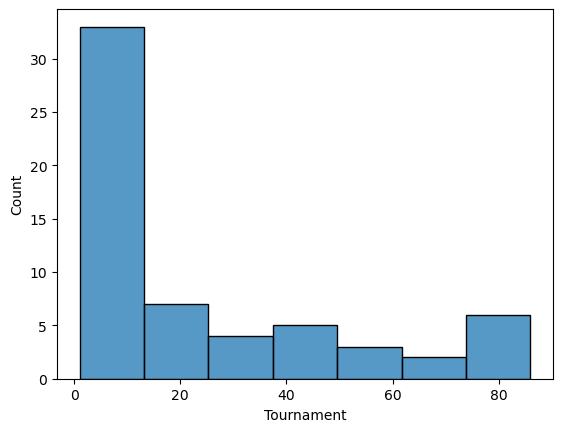

```python
sns.histplot(data=data,x='Tournament',stat='count')
plt.show()
```

- Most of the teams have played tournament count between 1 to 18

```python
data.loc[data['Tournament']<=18]['Tournament'].count()
```

```
37
```

```python
data.loc[data['Tournament']>18]['Tournament'].count()
```

```
23
```

- We can see total 37 teams are there who has played 18 or less tournaments
- There are 23 teams only who have played more than 18 tournaments

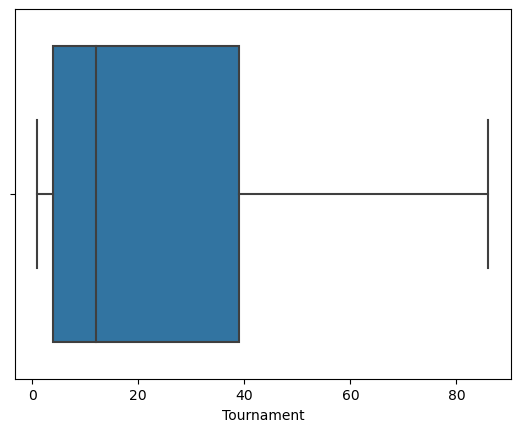

```python
sns.boxplot(data=data,x='Tournament')
plt.show()
```

- Tournament distribution is right skewed
- No outlier present in Tournament column

#### Observations on Score

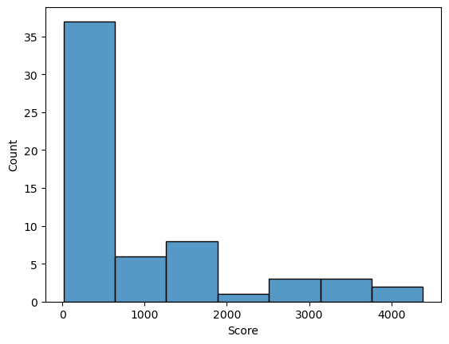

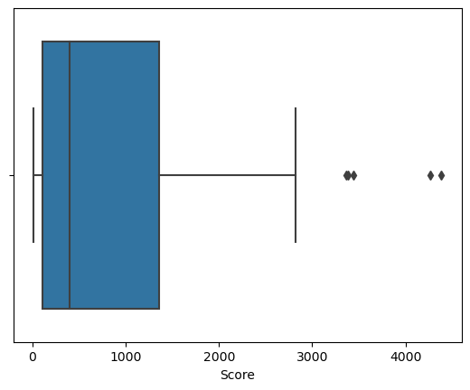

```python
sns.histplot(data=data,x='Score',stat='count')
plt.show()
sns.boxplot(data=data,x='Score')
plt.show()
```

```python
data.loc[data['Score']<=800]['Score'].count()
```

```
39
```

```python
data.loc[data['Score']>800]['Score'].count()
```

```
21
```

- We can see 39 out of 60 team has scored less than 800
- 21 teams has scored more than 800

```python
data['Score'].max()
```

```
4385
```

```python
data.loc[data['Tournament']>70]
```

|  | Team | Tournament | Score | PlayedGames | WonGames | DrawnGames | LostGames | BasketScored | BasketGiven | TournamentChampion | Runner-up | HighestPositionHeld | TeamLaunchStartYear | TeamLaunchEndYear |
| --- | --- | --- | --- | --- | --- | --- | --- | --- | --- | --- | --- | --- | --- | --- |
| 0 | Team 1 | 86 | 4385 | 2762 | 1647 | 552 | 563 | 5947 | 3140 | 33 | 23 | 1 | 1929 | 1929 |
| 1 | Team 2 | 86 | 4262 | 2762 | 1581 | 573 | 608 | 5900 | 3114 | 25 | 25 | 1 | 1929 | 1929 |
| 2 | Team 3 | 80 | 3442 | 2614 | 1241 | 598 | 775 | 4534 | 3309 | 10 | 8 | 1 | 1929 | 1929 |
| 3 | Team 4 | 82 | 3386 | 2664 | 1187 | 616 | 861 | 4398 | 3469 | 6 | 6 | 1 | 1931 | 1932 |
| 4 | Team 5 | 86 | 3368 | 2762 | 1209 | 633 | 920 | 4631 | 3700 | 8 | 7 | 1 | 1929 | 1929 |
| 5 | Team 6 | 73 | 2819 | 2408 | 990 | 531 | 887 | 3680 | 3373 | 1 | 4 | 1 | 1934 | 1935 |
| 6 | Team 7 | 82 | 2792 | 2626 | 948 | 608 | 1070 | 3609 | 3889 | 0 | 0 | 3 | 1929 | 1929 |

- We can see a few of the team only has played more than 70 matches and hence their sccore is high and coming as outlier
- Highest score is 4385 and Team 1 is highest scorer

#### Observation on PlayedGames

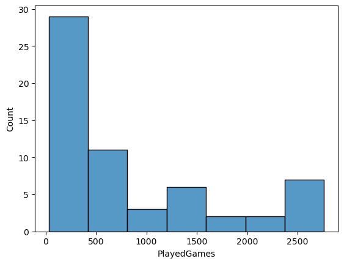

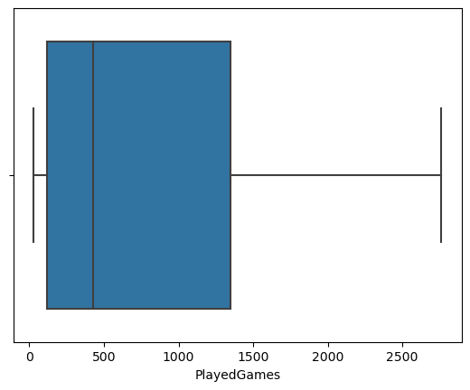

```python
sns.histplot(data=data,x='PlayedGames',stat='count')
plt.show()
sns.boxplot(data=data,x='PlayedGames')
plt.show()
```

- Most played game count lies between 1 and 450 around for most of the teams
- No outliers present in above boxplot
- PlayedGames distribution is skewed toward right

```python
data.loc[data['PlayedGames']<=450]['PlayedGames'].count()
```

```
32
```

- we can see 32 teams have played game count 450 or less and remaining 28 have played games count from 451 to 3000

#### Observations on WonGames

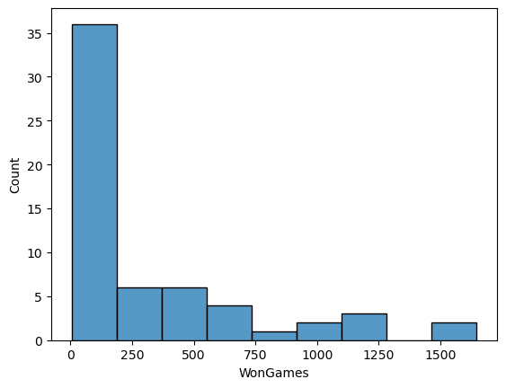

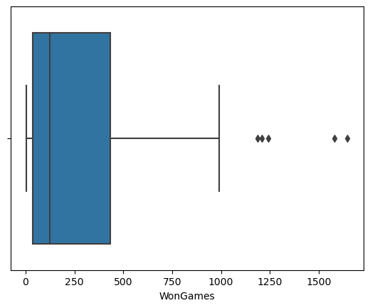

```python
sns.histplot(data=data,x='WonGames',stat='count')
plt.show()
sns.boxplot(data=data,x='WonGames')
plt.show()
```

- Most wongames count for most of the team lies between 1 to 200
- Above box plot is right skewed
- Few outliers are present but that seems to be correct because a few team has played comparitively more tournament than other teams, hence the wongames count is high for them

```python
data.loc[data['WonGames']<=200]['WonGames'].count()
```

```
37
```

- We can see 37 teams have won the games 200 or less times

#### Observation on other columns

- Looks similar observation as above, Let us plot them

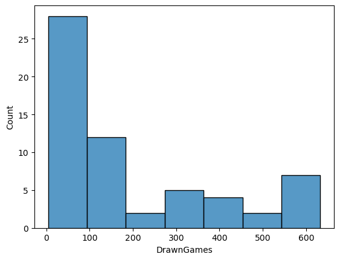

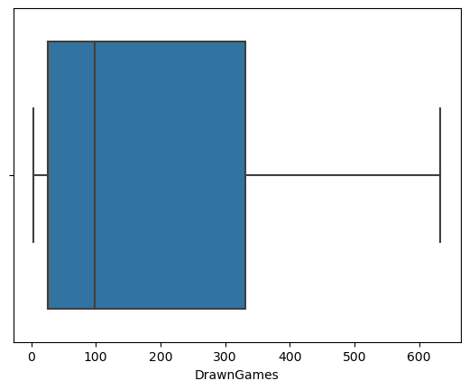

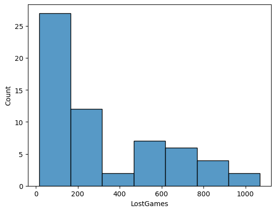

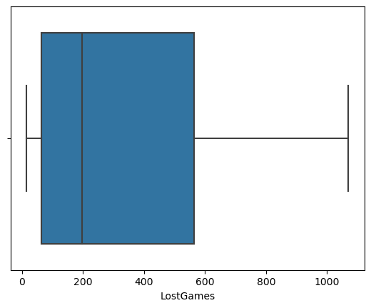

```python
#DrawnGames
sns.histplot(data=data,x='DrawnGames',stat='count')
plt.show()
sns.boxplot(data=data,x='DrawnGames')
plt.show()

#LostGames
sns.histplot(data=data,x='LostGames',stat='count')
plt.show()
sns.boxplot(data=data,x='LostGames')
plt.show()
```

- Similar Observation as above plots
- Most of the box plots are righ skewed

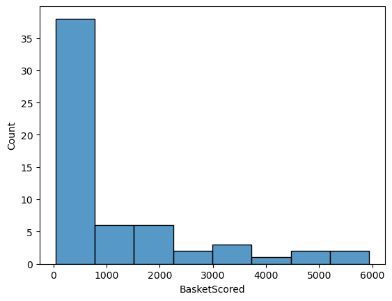

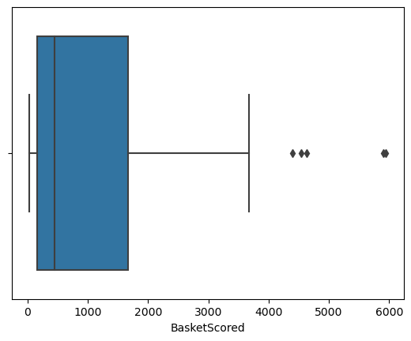

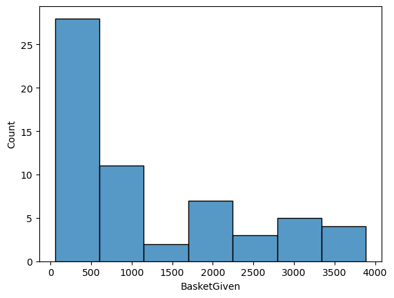

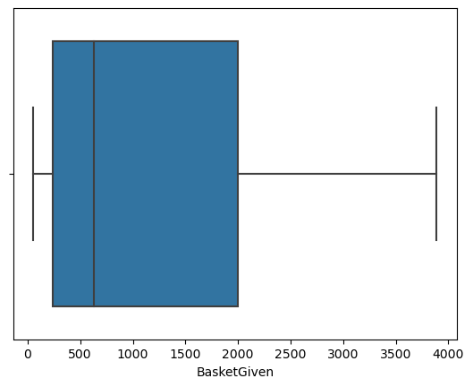

```python
#BasketScored
sns.histplot(data=data,x='BasketScored',stat='count')
plt.show()
sns.boxplot(data=data,x='BasketScored')
plt.show()

#BasketGiven
sns.histplot(data=data,x='BasketGiven',stat='count')
plt.show()
sns.boxplot(data=data,x='BasketGiven')
plt.show()
```

- Both BasketScored and BasketGiven is right skewed.
- BasketScored box plot has some outliers that should be due to a few teams played comparitively more matches. so those outliers are fine

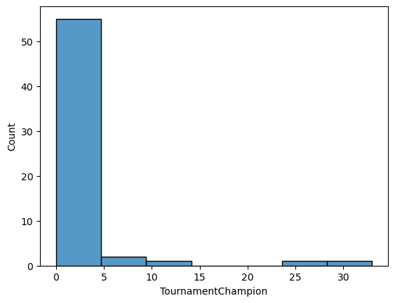

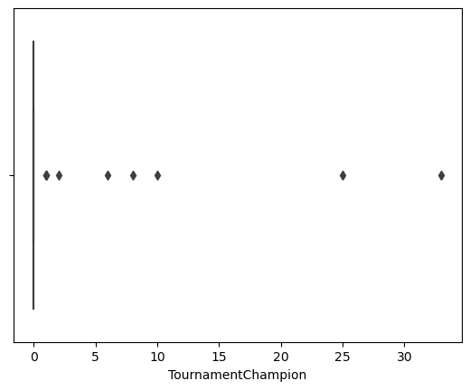

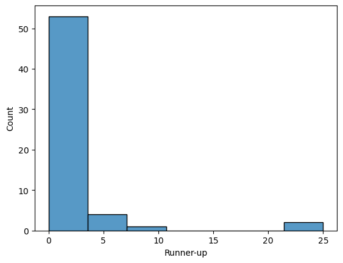

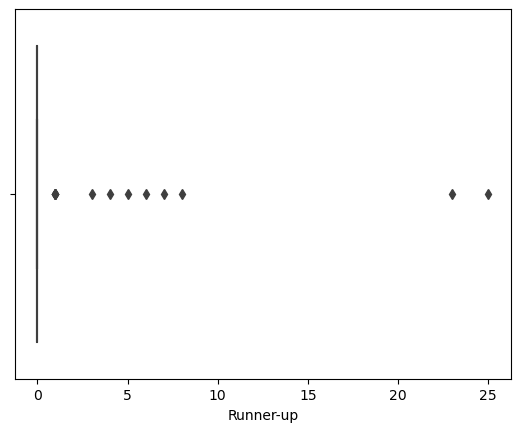

```python
#TournamentChampion
sns.histplot(data=data,x='TournamentChampion',stat='count')
plt.show()
sns.boxplot(data=data,x='TournamentChampion')
plt.show()

#Runner-up
sns.histplot(data=data,x='Runner-up',stat='count')
plt.show()
sns.boxplot(data=data,x='Runner-up')
plt.show()
```

- Very few teams have become tournamentchampion more than 22 times
- Very few teams have become runner-up more than 22 times
- Outliers are present in the both above box plots but that is fine as those outliers are due to most of the team have 0 times reached to the Tournamentchampion or Runner-up position

```python
data.loc[data['TournamentChampion']>22]
```

|  | Team | Tournament | Score | PlayedGames | WonGames | DrawnGames | LostGames | BasketScored | BasketGiven | TournamentChampion | Runner-up | HighestPositionHeld | TeamLaunchStartYear | TeamLaunchEndYear |
| --- | --- | --- | --- | --- | --- | --- | --- | --- | --- | --- | --- | --- | --- | --- |
| 0 | Team 1 | 86 | 4385 | 2762 | 1647 | 552 | 563 | 5947 | 3140 | 33 | 23 | 1 | 1929 | 1929 |
| 1 | Team 2 | 86 | 4262 | 2762 | 1581 | 573 | 608 | 5900 | 3114 | 25 | 25 | 1 | 1929 | 1929 |

- Only two teams have become tournament champion more than 22 times
- Team 1 has become highest(33) times Tournament champion
- Team 2 is on the second highest(25) times Tournament champion

```python
data.loc[data['Runner-up']>22]
```

|  | Team | Tournament | Score | PlayedGames | WonGames | DrawnGames | LostGames | BasketScored | BasketGiven | TournamentChampion | Runner-up | HighestPositionHeld | TeamLaunchStartYear | TeamLaunchEndYear |
| --- | --- | --- | --- | --- | --- | --- | --- | --- | --- | --- | --- | --- | --- | --- |
| 0 | Team 1 | 86 | 4385 | 2762 | 1647 | 552 | 563 | 5947 | 3140 | 33 | 23 | 1 | 1929 | 1929 |
| 1 | Team 2 | 86 | 4262 | 2762 | 1581 | 573 | 608 | 5900 | 3114 | 25 | 25 | 1 | 1929 | 1929 |

- Only two teams have become Runner-up more than 22 times
- Team 2 has become highest(25) number of times Runner-up
- Team 1 is on the second highest(23) number of times Runner-up

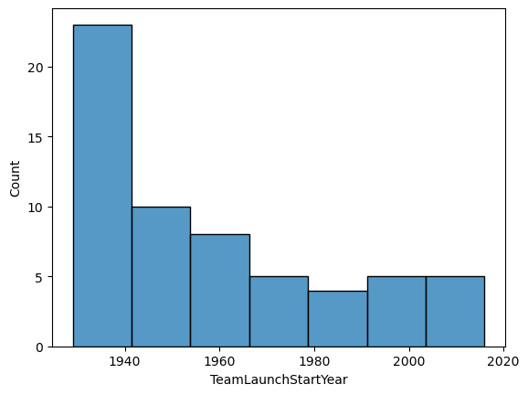

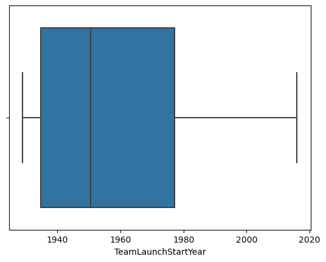

```python
sns.histplot(data=data,x='TeamLaunchStartYear',stat='count')
plt.show()
sns.boxplot(data=data,x='TeamLaunchStartYear')
plt.show()
```

- No outliers present in the above boxplot

```python
data['TeamLaunchStartYear'].value_counts()
```

```
1929    10
1941     3
1963     2
1977     2
1935     2
1951     2
1939     2
2016     1
1947     1
1994     1
1978     1
1971     1
1956     1
1999     1
2014     1
```

[output cut: 30 more lines]

- 10(highest) Teams played tournament in 1929

**Observation**

- Team 1 looks more experienced and strongest team as they have played total 86 tournaments and become 33 times tournament champion, 23 times Runner-up.

#### Bivariate & Multivariate Analysis

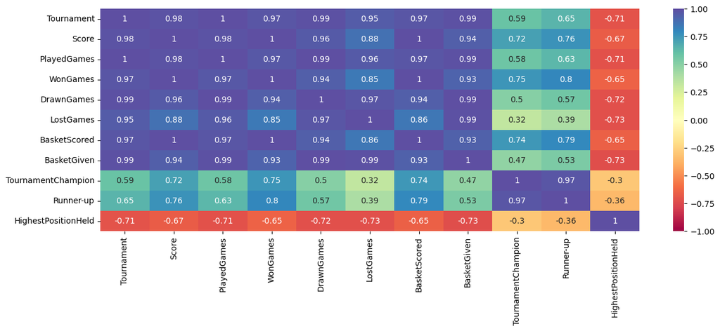

```python
plt.figure(figsize=(15,5))
datacorr = data[['Tournament','Score','PlayedGames','WonGames','DrawnGames','LostGames','BasketScored','BasketGiven',
                 'TournamentChampion','Runner-up','HighestPositionHeld']].corr()
sns.heatmap(datacorr,annot=True,cmap='Spectral',vmin=-1,vmax=1)
plt.show()
```

#### Observations

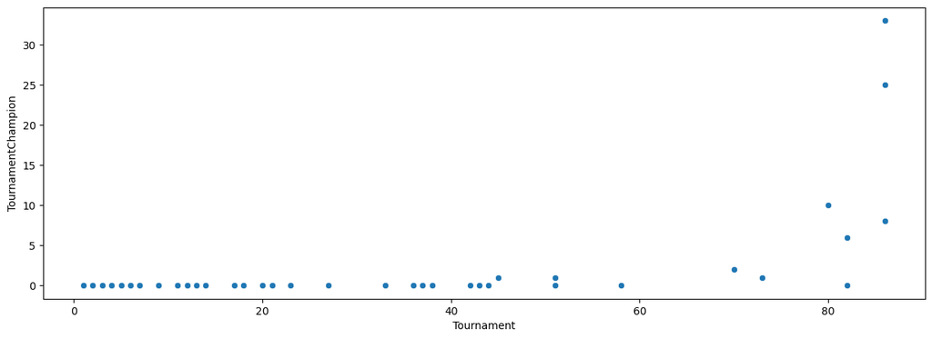

```python
plt.figure(figsize=(15,5))
sns.scatterplot(data=data,x='Tournament',y='TournamentChampion')
plt.show()
```

- Those who have played less than 60 Torunaments have not become more than 2 times Torunament champions
- Those who have played more than 60 Torunaments have become Torunament Champions more times

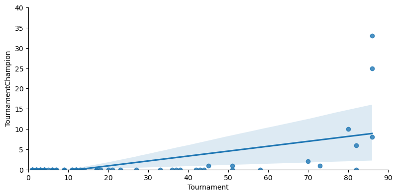

```python
sns.lmplot(data=data,x='Tournament',y='TournamentChampion',height=4,aspect=2)
plt.xlim(0,90)
plt.ylim(0,40)
plt.show()
```

- Shows Positive corelation

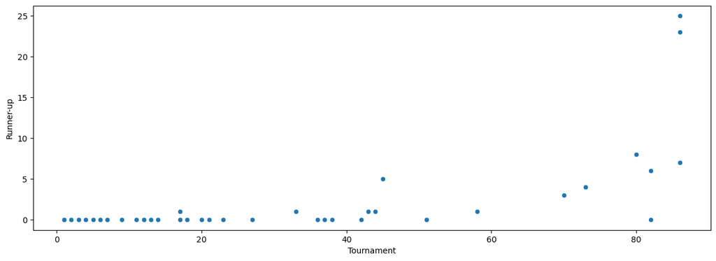

```python
plt.figure(figsize=(15,5))
sns.scatterplot(data=data,x='Tournament',y='Runner-up')
plt.show()
```

- Those who have played more than 80 Torunaments have become Runner-up more times

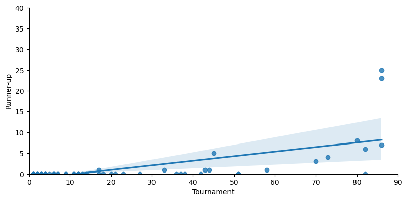

```python
sns.lmplot(data=data,x='Tournament',y='Runner-up',height=4,aspect=2)
plt.xlim(0,90)
plt.ylim(0,40)
plt.show()
```

- Shows Positive Co-relation

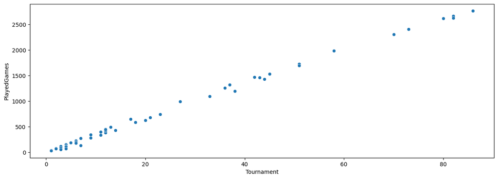

```python
plt.figure(figsize=(15,5))
sns.scatterplot(data=data,x='Tournament',y='PlayedGames')
plt.show()
```

- Strong positive corelation between Torunament and PlayedGames. The more number of Tournaments played, the more number of playedgames.

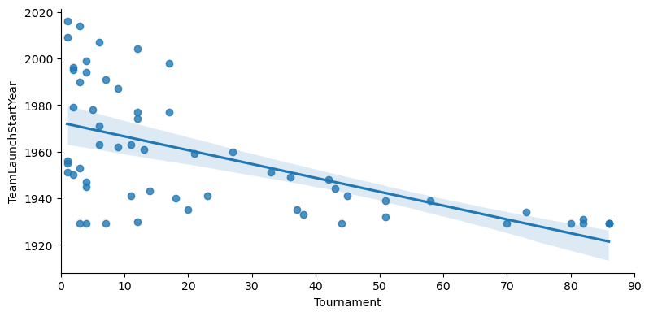

```python
sns.lmplot(data=data,x='Tournament',y='TeamLaunchStartYear',height=4,aspect=2)
plt.xlim(0,90)
plt.show()
```

- Negative corelation between TeamLaunchStartYear and Tournament i.e as the year increasing we played less torunament

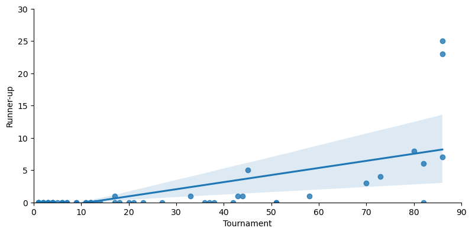

```python
sns.lmplot(data=data,x='Tournament',y='Runner-up',height=4,aspect=2)
plt.xlim(0,90)
plt.ylim(0,30)
plt.show()
```